# Case study : Fitbit Data for Bellabeat

Feronika

2024-03-04

# Case Study 2: How Can a Wellness Technology

Company Play It Smart?

# About:

This capstone project was conducted in RStudio as part of my Google Data Analytics Professional Certificate course.

# Scenario:

As a junior data analyst on Bellabeat’s marketing team, tasked with analyzing smart device data, I aim to uncover insights to drive marketing strategy for the company’s products. Urška Sršen, Bellabeat’s cofounder and Chief Creative Officer, believes that analyzing smart device fitness data could unlock growth opportunities for the company.

# Business Task:

Analyze smart device usage data to understand consumer behavior with non-Bellabeat devices and apply these insights to Bellabeat’s products.

# Stakeholders:

Urška Sršen: Bellabeat’s cofounder and Chief Creative Officer Sando Mur: Mathematician and Bellabeat’s cofounder Bellabeat marketing manager and their analytics team

# Data Source:

The data consists of Fitbit Fitness Tracker data obtained from Kaggle. About 30 Fitbit users allowed collection of personal tracker data on their active time, sleep, and heart rate for one month (04/12/2016-05/12/2016). A total of 18 CSV files are available. [Link Text](https://www.kaggle.com/datasets/arashnic/fitbit)

# How does the data help in answering the business questions?

The data’s reliability is limited due to its small sample size and lack of gender specificity.

It is sourced from a third party, collected via Amazon Mechanical Turk, reducing its originality.

The data provides moderately comprehensive insights into daily activity intensity, calories burned, steps taken, sleep time, and weight.

However, its relevance may be impacted as it was collected in 2016, potentially affecting the representation of users’ current habits. Data citation is limited as it lacks key descriptive information about its collection.

## Install packages and loading library

```r
install.packages("tidyverse")
library(tidyverse)
install.packages("here")
library(here)
install.packages("skimr")
library(skimr)
install.packages("janitor")
library(janitor)
```

## Importing dataset

```r
DailyActivity <- read.csv("dailyActivity_merged.csv")
HeartRate <- read.csv("heartrate_seconds_merged.csv")
SleepDay <- read.csv("sleepDay_merged.csv")
```

## Inspecting and cleaning data

```r
skim_without_charts(DailyActivity)
```

Data summary

| Name | DailyActivity |
| --- | --- |
| Number of rows | 940 |
| Number of columns | 15 |
| _______________________ |  |
| Column type frequency: |  |
| character | 1 |
| numeric | 14 |
| ________________________ |  |
| Group variables | None |

**Variable type: character**

| skim_variable | n_missing | complete_rate | min | max | empty | n_unique | whitespace |
| --- | --- | --- | --- | --- | --- | --- | --- |
| ActivityDate | 0 | 1 | 8 | 9 | 0 | 31 | 0 |

**Variable type: numeric**

| skim_variable | n_missing | complete_rate | mean | sd | p0 | p25 | p50 | p75 | p100 |
| --- | --- | --- | --- | --- | --- | --- | --- | --- | --- |
| Id | 0 | 1 | 4.855407e+09 | 2.424805e+09 | 1503960366 | 2.320127e+09 | 4.445115e+09 | 6.962181e+09 | 8.877689e+09 |
| TotalSteps | 0 | 1 | 7.637910e+03 | 5.087150e+03 | 0 | 3.789750e+03 | 7.405500e+03 | 1.072700e+04 | 3.601900e+04 |
| TotalDistance | 0 | 1 | 5.490000e+00 | 3.920000e+00 | 0 | 2.620000e+00 | 5.240000e+00 | 7.710000e+00 | 2.803000e+01 |
| TrackerDistance | 0 | 1 | 5.480000e+00 | 3.910000e+00 | 0 | 2.620000e+00 | 5.240000e+00 | 7.710000e+00 | 2.803000e+01 |
| LoggedActivitiesDistance | 0 | 1 | 1.100000e-01 | 6.200000e-01 | 0 | 0.000000e+00 | 0.000000e+00 | 0.000000e+00 | 4.940000e+00 |
| VeryActiveDistance | 0 | 1 | 1.500000e+00 | 2.660000e+00 | 0 | 0.000000e+00 | 2.100000e-01 | 2.050000e+00 | 2.192000e+01 |
| ModeratelyActiveDistance | 0 | 1 | 5.700000e-01 | 8.800000e-01 | 0 | 0.000000e+00 | 2.400000e-01 | 8.000000e-01 | 6.480000e+00 |
| LightActiveDistance | 0 | 1 | 3.340000e+00 | 2.040000e+00 | 0 | 1.950000e+00 | 3.360000e+00 | 4.780000e+00 | 1.071000e+01 |
| SedentaryActiveDistance | 0 | 1 | 0.000000e+00 | 1.000000e-02 | 0 | 0.000000e+00 | 0.000000e+00 | 0.000000e+00 | 1.100000e-01 |
| VeryActiveMinutes | 0 | 1 | 2.116000e+01 | 3.284000e+01 | 0 | 0.000000e+00 | 4.000000e+00 | 3.200000e+01 | 2.100000e+02 |
| FairlyActiveMinutes | 0 | 1 | 1.356000e+01 | 1.999000e+01 | 0 | 0.000000e+00 | 6.000000e+00 | 1.900000e+01 | 1.430000e+02 |
| LightlyActiveMinutes | 0 | 1 | 1.928100e+02 | 1.091700e+02 | 0 | 1.270000e+02 | 1.990000e+02 | 2.640000e+02 | 5.180000e+02 |
| SedentaryMinutes | 0 | 1 | 9.912100e+02 | 3.012700e+02 | 0 | 7.297500e+02 | 1.057500e+03 | 1.229500e+03 | 1.440000e+03 |
| Calories | 0 | 1 | 2.303610e+03 | 7.181700e+02 | 0 | 1.828500e+03 | 2.134000e+03 | 2.793250e+03 | 4.900000e+03 |

```r
skim_without_charts(HeartRate)
```

Data summary

| Name | HeartRate |
| --- | --- |
| Number of rows | 2483658 |
| Number of columns | 3 |
| _______________________ |  |
| Column type frequency: |  |
| character | 1 |
| numeric | 2 |
| ________________________ |  |
| Group variables | None |

**Variable type: character**

| skim_variable | n_missing | complete_rate | min | max | empty | n_unique | whitespace |
| --- | --- | --- | --- | --- | --- | --- | --- |
| Time | 0 | 1 | 19 | 21 | 0 | 961274 | 0 |

**Variable type: numeric**

| skim_variable | n_missing | complete_rate | mean | sd | p0 | p25 | p50 | p75 | p100 |
| --- | --- | --- | --- | --- | --- | --- | --- | --- | --- |
| Id | 0 | 1 | 5.513765e+09 | 1950223761.0 | 2022484408 | 4388161847 | 5553957443 | 6962181067 | 8877689391 |
| Value | 0 | 1 | 7.733000e+01 | 19.4 | 36 | 63 | 73 | 88 | 203 |

```r
skim_without_charts(SleepDay)
```

Data summary

| Name | SleepDay |
| --- | --- |
| Number of rows | 413 |
| Number of columns | 5 |
| _______________________ |  |
| Column type frequency: |  |
| character | 1 |
| numeric | 4 |
| ________________________ |  |
| Group variables | None |

**Variable type: character**

| skim_variable | n_missing | complete_rate | min | max | empty | n_unique | whitespace |
| --- | --- | --- | --- | --- | --- | --- | --- |
| SleepDay | 0 | 1 | 20 | 21 | 0 | 31 | 0 |

**Variable type: numeric**

| skim_variable | n_missing | complete_rate | mean | sd | p0 | p25 | p50 | p75 | p100 |
| --- | --- | --- | --- | --- | --- | --- | --- | --- | --- |
| Id | 0 | 1 | 5.000979e+09 | 2.06036e+09 | 1503960366 | 3977333714 | 4702921684 | 6962181067 | 8792009665 |
| TotalSleepRecords | 0 | 1 | 1.120000e+00 | 3.50000e-01 | 1 | 1 | 1 | 1 | 3 |
| TotalMinutesAsleep | 0 | 1 | 4.194700e+02 | 1.18340e+02 | 58 | 361 | 433 | 490 | 796 |
| TotalTimeInBed | 0 | 1 | 4.586400e+02 | 1.27100e+02 | 61 | 403 | 463 | 526 | 961 |

```r
glimpse(DailyActivity)
```

```
## Rows: 940
## Columns: 15
## $ Id                       <dbl> 1503960366, 1503960366, 1503960366, 150396036…
## $ ActivityDate             <chr> "4/12/2016", "4/13/2016", "4/14/2016", "4/15/…
## $ TotalSteps               <int> 13162, 10735, 10460, 9762, 12669, 9705, 13019…
## $ TotalDistance            <dbl> 8.50, 6.97, 6.74, 6.28, 8.16, 6.48, 8.59, 9.8…
## $ TrackerDistance          <dbl> 8.50, 6.97, 6.74, 6.28, 8.16, 6.48, 8.59, 9.8…
## $ LoggedActivitiesDistance <dbl> 0, 0, 0, 0, 0, 0, 0, 0, 0, 0, 0, 0, 0, 0, 0, …
## $ VeryActiveDistance       <dbl> 1.88, 1.57, 2.44, 2.14, 2.71, 3.19, 3.25, 3.5…
## $ ModeratelyActiveDistance <dbl> 0.55, 0.69, 0.40, 1.26, 0.41, 0.78, 0.64, 1.3…
## $ LightActiveDistance      <dbl> 6.06, 4.71, 3.91, 2.83, 5.04, 2.51, 4.71, 5.0…
## $ SedentaryActiveDistance  <dbl> 0, 0, 0, 0, 0, 0, 0, 0, 0, 0, 0, 0, 0, 0, 0, …
## $ VeryActiveMinutes        <int> 25, 21, 30, 29, 36, 38, 42, 50, 28, 19, 66, 4…
## $ FairlyActiveMinutes      <int> 13, 19, 11, 34, 10, 20, 16, 31, 12, 8, 27, 21…
## $ LightlyActiveMinutes     <int> 328, 217, 181, 209, 221, 164, 233, 264, 205, …
## $ SedentaryMinutes         <int> 728, 776, 1218, 726, 773, 539, 1149, 775, 818…
## $ Calories                 <int> 1985, 1797, 1776, 1745, 1863, 1728, 1921, 203…
```

```r
glimpse(HeartRate)
```

```
## Rows: 2,483,658
## Columns: 3
## $ Id    <dbl> 2022484408, 2022484408, 2022484408, 2022484408, 2022484408, 2022…
## $ Time  <chr> "4/12/2016 7:21:00 AM", "4/12/2016 7:21:05 AM", "4/12/2016 7:21:…
## $ Value <int> 97, 102, 105, 103, 101, 95, 91, 93, 94, 93, 92, 89, 83, 61, 60, …
```

```r
glimpse(SleepDay)
```

```
## Rows: 413
## Columns: 5
## $ Id                 <dbl> 1503960366, 1503960366, 1503960366, 1503960366, 150…
## $ SleepDay           <chr> "4/12/2016 12:00:00 AM", "4/13/2016 12:00:00 AM", "…
## $ TotalSleepRecords  <int> 1, 2, 1, 2, 1, 1, 1, 1, 1, 1, 1, 1, 1, 1, 1, 1, 1, …
## $ TotalMinutesAsleep <int> 327, 384, 412, 340, 700, 304, 360, 325, 361, 430, 2…
## $ TotalTimeInBed     <int> 346, 407, 442, 367, 712, 320, 377, 364, 384, 449, 3…
```

## Convert date to appropriate format

```r
DailyActivity$ActivityDate <- mdy(DailyActivity$ActivityDate)
HeartRate$Time  <- mdy_hms(HeartRate$Time)
SleepDay$SleepDay <- mdy(SleepDay$SleepDay)
DailyActivity <- clean_names(DailyActivity)
HeartRate  <- clean_names(HeartRate)
SleepDay  <- clean_names(SleepDay)
```

## Statistical summary for distance category

```r
DailyActivity %>%
  select(very_active_distance,
         moderately_active_distance,
         light_active_distance,
         sedentary_active_distance) %>%
  summary()
```

```
##  very_active_distance moderately_active_distance light_active_distance
##  Min.   : 0.000       Min.   :0.0000             Min.   : 0.000
##  1st Qu.: 0.000       1st Qu.:0.0000             1st Qu.: 1.945
##  Median : 0.210       Median :0.2400             Median : 3.365
##  Mean   : 1.503       Mean   :0.5675             Mean   : 3.341
##  3rd Qu.: 2.053       3rd Qu.:0.8000             3rd Qu.: 4.782
##  Max.   :21.920       Max.   :6.4800             Max.   :10.710
##  sedentary_active_distance
##  Min.   :0.000000
##  1st Qu.:0.000000
##  Median :0.000000
##  Mean   :0.001606
##  3rd Qu.:0.000000
##  Max.   :0.110000
```

Maximum distance: 28.030 and Mean distance: 5.490

## Statistical summary for minutes category

```r
DailyActivity %>%
  select(total_steps,
         very_active_minutes,
         fairly_active_minutes,
         lightly_active_minutes,
         sedentary_minutes,
         calories) %>%
  summary()
```

```
##   total_steps    very_active_minutes fairly_active_minutes
##  Min.   :    0   Min.   :  0.00      Min.   :  0.00
##  1st Qu.: 3790   1st Qu.:  0.00      1st Qu.:  0.00
##  Median : 7406   Median :  4.00      Median :  6.00
##  Mean   : 7638   Mean   : 21.16      Mean   : 13.56
##  3rd Qu.:10727   3rd Qu.: 32.00      3rd Qu.: 19.00
##  Max.   :36019   Max.   :210.00      Max.   :143.00
##  lightly_active_minutes sedentary_minutes    calories
##  Min.   :  0.0          Min.   :   0.0    Min.   :   0
##  1st Qu.:127.0          1st Qu.: 729.8    1st Qu.:1828
##  Median :199.0          Median :1057.5    Median :2134
##  Mean   :192.8          Mean   : 991.2    Mean   :2304
##  3rd Qu.:264.0          3rd Qu.:1229.5    3rd Qu.:2793
##  Max.   :518.0          Max.   :1440.0    Max.   :4900
```

Max steps: 36019 (avg. 7638). Mean calories burned: 2304, max: 4900. (Note: Most female adults aim for 1,600–2,200 daily calories burnt and 6,000 to 10,000 steps)

## Statistical summary and visualization

```r
avg_intensity_levels <- DailyActivity %>%
            summarize(very_active_distance = mean(very_active_distance),
                      moderately_active_distance = mean(moderately_active_distance),
                      light_active_distance = mean(light_active_distance),
                      sedentary_active_distance = mean(sedentary_active_distance))
```

## Pivot from wide to long

```r
avg_intensity_levels_long <- avg_intensity_levels %>%
        pivot_longer(cols = c(very_active_distance,
                               moderately_active_distance,
                              light_active_distance,
                               sedentary_active_distance ),
                      names_to = "avg_intensity_levels",
                      values_to = "kilometer")

avg_intensity_levels_long
```

```
## # A tibble: 4 × 2
##   avg_intensity_levels       kilometer
##   <chr>                          <dbl>
## 1 very_active_distance         1.50
## 2 moderately_active_distance   0.568
## 3 light_active_distance        3.34
## 4 sedentary_active_distance    0.00161
```

## Visualization of avg_intensity_levels

### Install and loading ggplot

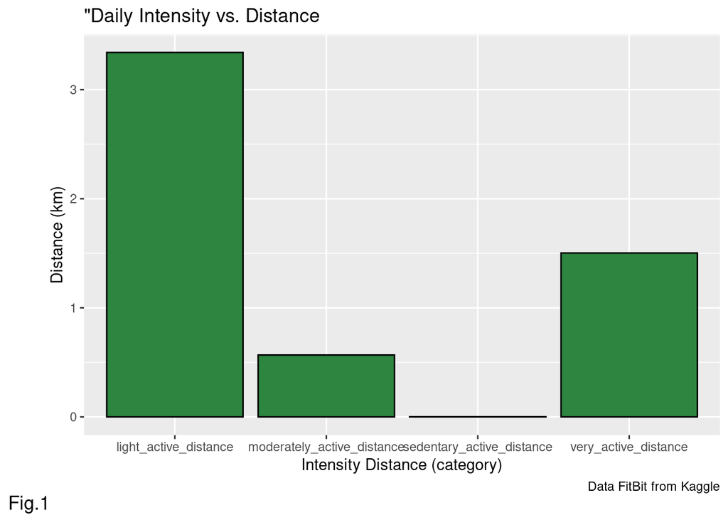

```r
install.packages("ggplot2")
library(ggplot2)

ggplot(data = avg_intensity_levels_long,
       aes (x = avg_intensity_levels, y=kilometer)) +
       geom_col(fill= '#2e8540', color ='black') +
       xlab('Intensity Distance (category)') +
       ylab('Distance (km)') +
       labs(title = '"Daily Intensity vs. Distance',
       caption = 'Data FitBit from Kaggle',
       tag = 'Fig.1') +
       theme(plot.tag.position = 'bottomleft')
```

According to the figure, people labeled as “light active” cover more distance in kilometers on average compared to those labeled as “very active.”

## Visualization of avg_minutes_levels

```r
avg_minutes_levels <- DailyActivity %>%
  summarize(very_active_minutes = mean(very_active_minutes),
            fairly_active_minutes = mean(fairly_active_minutes),
            lightly_active_minutes = mean(lightly_active_minutes),
            sedentary_minutes = mean(sedentary_minutes))
avg_minutes_levels
```

```
##   very_active_minutes fairly_active_minutes lightly_active_minutes
## 1            21.16489              13.56489               192.8128
##   sedentary_minutes
## 1          991.2106
```

## Pivot from wide to long

```r
avg_minutes_levels_long <- avg_minutes_levels %>%
  pivot_longer(cols = c(very_active_minutes,
                        fairly_active_minutes,
                        lightly_active_minutes,
                        sedentary_minutes ),
               names_to = "avg_active_duration",
               values_to = "minutes")
avg_minutes_levels_long
```

```
## # A tibble: 4 × 2
##   avg_active_duration    minutes
##   <chr>                    <dbl>
## 1 very_active_minutes       21.2
## 2 fairly_active_minutes     13.6
## 3 lightly_active_minutes   193.
## 4 sedentary_minutes        991.
```

## Visualization of avg_minutes_levels

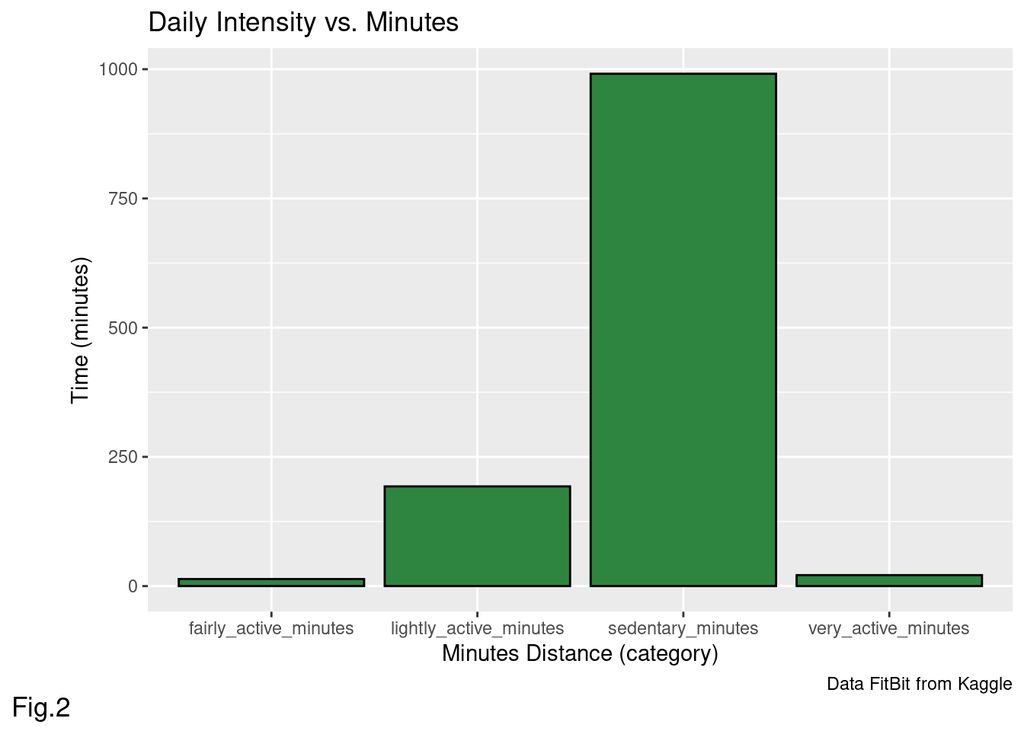

```r
ggplot(data = avg_minutes_levels_long,
       aes (x = avg_active_duration, y=minutes)) +
  geom_col(fill= '#2e8540',color='black' ) +
  xlab('Minutes Distance (category)') +
  ylab('Time (minutes)') +
  labs(title = 'Daily Intensity vs. Minutes',
       caption = 'Data FitBit from Kaggle',
       tag = 'Fig.2') +
  theme(plot.tag.position = 'bottomleft')
```

Most individuals spend a significant amount of time engaged in sedentary activities, followed by lightly active pursuits. Encouraging more moderate and vigorous activity could promote better wellness.

## Discovering the relationship between total steps and calories burnt per weeek

### Understanding the beginning and end of the observation.

```r
max_date <- max(DailyActivity$activity_date)
max_date
```

```
## [1] "2016-05-12"
```

```r
min_date <- min(DailyActivity$activity_date)
min_date
```

```
## [1] "2016-04-12"
```

```r
daily_activity <- DailyActivity %>%
  mutate(week = case_when(
    between(activity_date, as.Date('2016-04-12'), as.Date('2016-04-19'))~ 'week_1',
    between(activity_date, as.Date('2016-04-20'), as.Date('2016-04-27'))~ 'week_2',
    between(activity_date, as.Date('2016-04-28'), as.Date('2016-05-05'))~ 'week_3',
    between(activity_date, as.Date('2016-05-06'), as.Date('2016-05-13'))~ 'week_4',
    TRUE ~ 'NA'))
```

```r
calories_per_step <- daily_activity %>%
  select(activity_date, total_steps, week,calories) %>%
  filter(week == 'week_1'|week == 'week_2'|week == 'week_3'|week == 'week_4')
```

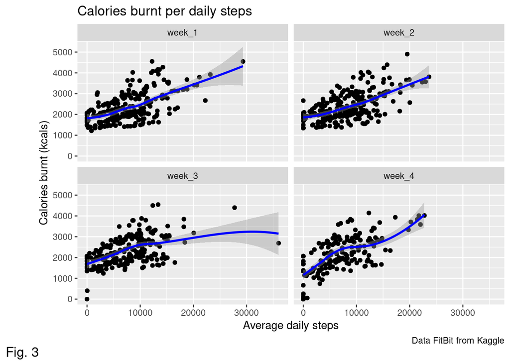

```r
ggplot(data = calories_per_step, aes(x = total_steps, y =calories)) +
  geom_point(color = 'black') +
  geom_smooth(color = 'blue') +
  facet_wrap(~week) +
  xlab('Average daily steps') +
  ylab ('Calories burnt (kcals)') +
  labs(title = 'Calories burnt per daily steps',
      caption = 'Data FitBit from Kaggle',
      tag = 'Fig. 3') +
      theme(plot.tag.position = 'bottomleft')
```

There’s a positive correlation between daily steps and calories burned. While the trendline initially dips towards the peak in the 3rd week, overall, the trend continues to move forward into the 4th week.

## Visualization between total time in bed and total minutes sleep

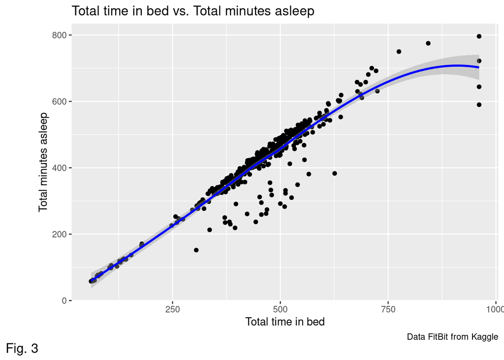

```r
ggplot(data = SleepDay, aes(x = total_time_in_bed , y =total_minutes_asleep)) +
  geom_point(color = 'black') +
  geom_smooth(color = 'blue') +
  xlab('Total time in bed') +
  ylab ('Total minutes asleep') +
  labs(title = 'Total time in bed vs. Total minutes asleep',
       caption = 'Data FitBit from Kaggle',
       tag = 'Fig. 3') +
  theme(plot.tag.position = 'bottomleft')
```

More time spent in bed correlates with a higher total duration of sleep, suggesting a positive relationship between time in bed and total sleep duration.

## Insight

Users cover more distance while lightly active (3.3km) compared to very active (1.5km), indicating that slow and steady activity yields greater distance. Additionally, users spend an average of 21 minutes very active per day and over 16 hours inactive

As daily steps increase, so do calories burned, suggesting a potential avenue for achieving desired weight goals.

## Recommendations to stakeholders:

-Offer free trial days to allow users to experience the app’s benefits before committing to a subscription.

-Implement app notifications to encourage users to be more active, thus reducing inactive time.